# PSY9550 Chapter 5

Author

Alexandra & Winnie

Published

March 6, 2024

# Clarification and or discussion questions

We are unsure of 5E4.

# Chapter 5 (all easy exercises)

- Chapter 5: E1-4, M1-3

## 5E1. Which of the linear models below are multiple linear regressions?

Model (2) and (4) due to the incorporation of the addition of two different variables with their own weight/effect/betas.

## 5E2.

**Write down a multiple regression to evaluate the claim: Animal diversity is linearly related to latitude, but only after controlling for plant diversity. You just need to write down the model definition.**

we assume that plant diversity (P) also has a linear relationship to animal diversity (A)

$$C = constant \\
Animal diversity (A) \sim Normal(\mu, \sigma)\\
\mu = C + \beta_P*Plant diversity (P) + \beta_L*Latitude(L)$$

## 5E3.

**Write down a multiple regression to evaluate the claim: Neither amount of funding nor size of laboratory is by itself a good predictor of time to PhD degree; but together these variables are both positively associated with time to degree. Write down the model definition and indicate which side of zero each slope parameter should be on.**

Outcome variable = time to finish PhD (T) Predictor variables = funding(F), size of laboratory (L)

Since each predictor variable is described as bad predictor for T, it is a sign that the predictors have a negative relationship (opposite). Would believe that increased funding would be a good think for finished the PhD (unless it would have the effect of stressing the student less and therefore give them extra time to finish the degree?), so based on T ~ F having a positive relationship, T ~ L is assumed to have a negative one (I do not have any experience with lab work myself).

Though, does the question inquire a correlation between the predicting variables. Then we should add an interaction term between the two predictors.

$$C = constant \\
Time to finish PhD (T) \sim Normal(\mu, \sigma)\\
\mu = C + \beta_F*Funding (F) + \beta_L*Sizelab(L) + \beta_FT*F*T$$

## 5E4.

**Suppose you have a single categorical predictor with 4 levels (unique values), labeled A, B, C and D. Let Ai be an indicator variable that is 1 where case i is in category A. Also suppose Bi, Ci, and Di for the other categories.**

**Now which of the following linear models are inferentially equivalent ways to include the categorical variable in a regression? Models are inferentially equivalent when it’s possible to compute one posterior distribution from the posterior distribution of another model.**

Winnie: wow, have no idea: 1 and 3? At least not 2. Alex: 2 and 5 are inferentially equivalent.

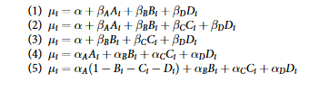

# Chapter 5 - Medium (M1-M3)

## 5M1. spurious

**Invent your own example of a spurious correlation. An outcome variable should be correlated with both predictor variables. But when both predictors are entered in the same model, the correlation between the outcome and one of the predictors should mostly vanish (or at least be greatly reduced).**

Outcome variable = number of wrinkles an individual has (W)

Predictors: capital wealth (C), age (A).

Capital wealth usually increases with age, and might serve as a proxy variable for age when predicting number of wrinkles a person has. Though when we do have data on age (A) and uses this in the model, it will hopefully allocate the strongest correlation with age and not capital wealth (C).

## 5M2. masked

**Invent your own example of a masked relationship. An outcome variable should be correlated with both predictor variables, but in opposite directions. And the two predictor variables should be correlated with one another.**

Outcome = share of active modes users in a city (AM)

Predictor variables = density of city (D) and share of car users (C)

AM ~ D is positive

AM ~ C is negative

D ~ C is negatively correlated.

Since the total sum shares of transport users must add to 1, AM and C is negative correlated. But the real cause of the increase in bicyclists and pedestrians is usually the density of functions (destinations) in a city, making it possible to make errands within reasonable time (without having to resort to car use). Also high-density cities often allocate relatively less space to car infrastructure and therefor making it a less attractive transport mode.

In this case share of car users (C) could mask for density of the city (D)

## 5M3.

**It is sometimes observed that the best predictor of fire risk is the presence of firefighters-States and localities with many firefighters also have more fires. Presumably firefighters do not cause fires. Nevertheless, this is not a spurious correlation. Instead fires cause firefighters.**

**Consider the same reversal of causal inference in the context of the divorce and marriage data. How might a high divorce rate cause a higher marriage rate? Can you think of a way to evaluate this relationship, using multiple regression?**

To try to find an explanation for how high divorce rates may cause higher marriage rates, we could assume that divorcees would be able to marry again after the divorce.

This mechanism/theory could be evaluated using a multiple regression by having a separate variable for post-divorce marriages rates.

# Hard (foxes)

**All three exercises below use the same data, data(foxes) (part of rethinking). The urban fox (Vulpes vulpes) is a successful exploiter of human habitat. Since urban foxes move in packs and defend territories, data on habitat quality and population density is also included. The data frame has five columns:**

**(1) group: Number of the social group the individual fox belongs to**

**(2) avgfood: The average amount of food available in the territory**

**(3) groupsize: The number of foxes in the social group**

**(4) area: Size of the territory**

**(5) weight: Body weight of the individual fox**

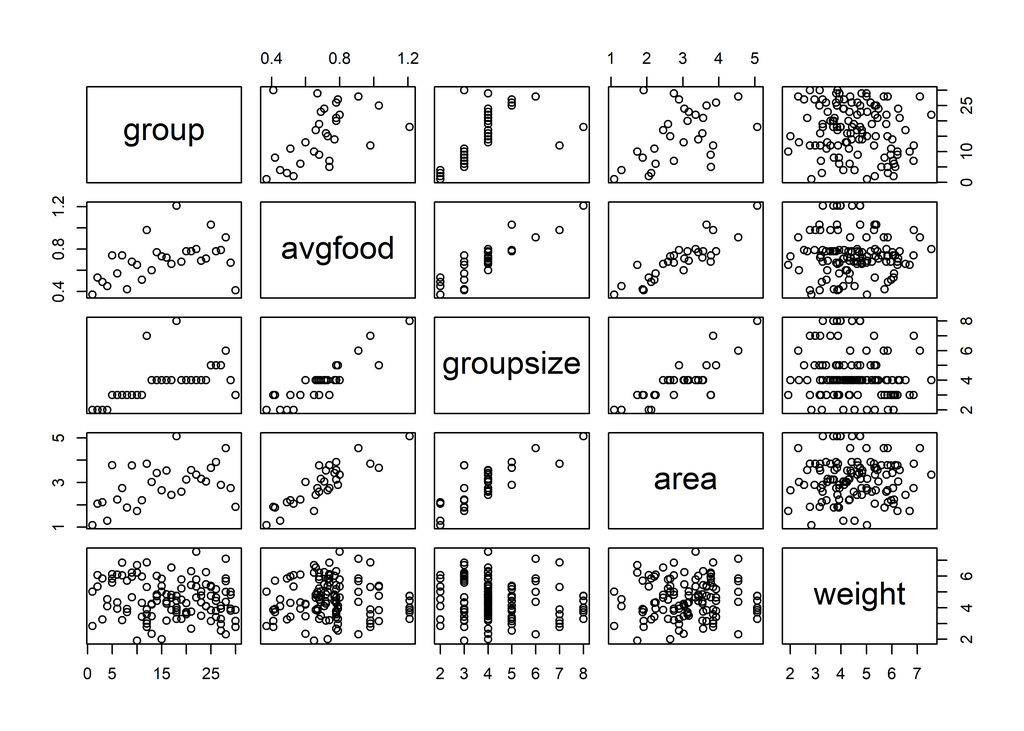

```r
data("foxes")

pairs(foxes)
```

```r
foxes <- foxes %>%
  mutate(across(avgfood:weight, ~ standardize(.), .names = "{col}_std"))
```

## 5H1. plot two bivariate models

**Fit two bivariate Gaussian regressions, using quap: (1) body weight as a linear function of territory size (area), and (2) body weight as a linear function of groupsize. Plot the results of these regressions, displaying the MAP regression line and the 95% interval of the mean. Is either variable important for predicting fox body weight?**

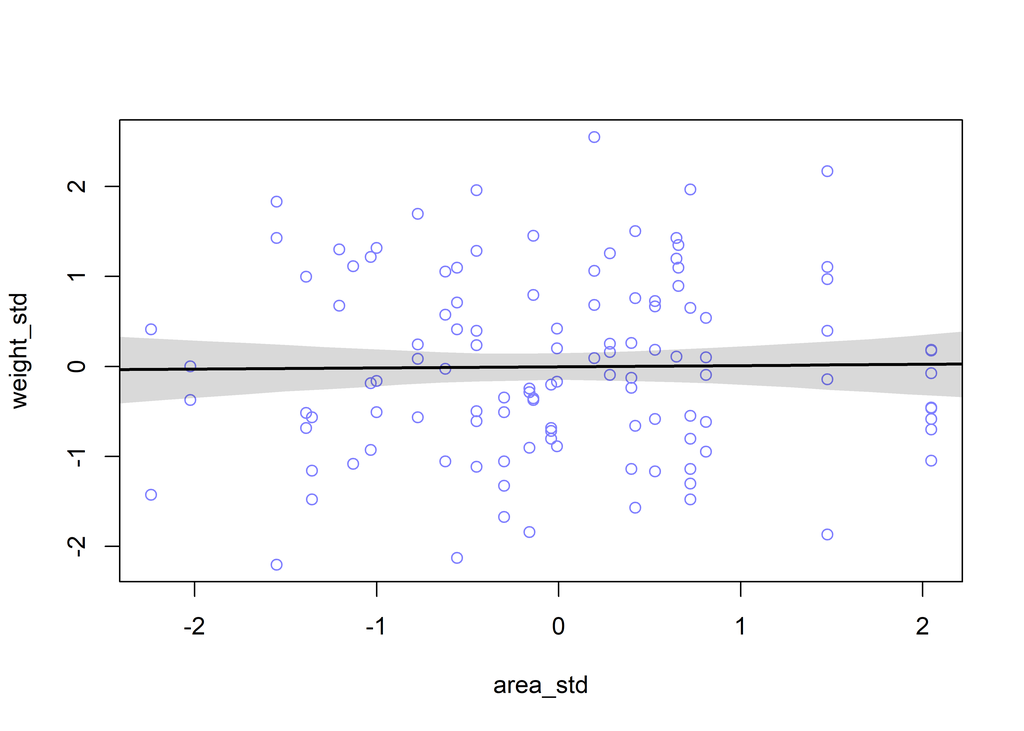

```r
# First model: weight ~ area size
body_area_model <- quap(
alist(
  weight_std ~ dnorm(mu, sigma),
  mu <- a + b_a*area_std,
    a ~ dnorm( 0 , 0.5 ) ,
    b_a ~ dnorm( 0 , 0.5 ) ,
    sigma ~ dexp( 1 )
  ) , data = foxes )

# Second model: weight ~ group size
body_grsize_model <- quap(
alist(
  weight_std ~ dnorm(mu, sigma),
  mu <- a + b_size*groupsize_std,
    a ~ dnorm( 0 , 0.5 ) ,
    b_size ~ dnorm( 0 , 0.5 ) ,
    sigma ~ dexp( 1 )
  ) , data = foxes )


# plotting the first model: body weight ~ area size
x_seq <- seq( from=-3 , to=3.2 , length.out=30 )
mu <- link( body_area_model , data=list(area_std = x_seq) )
mu.mean <- apply( mu , 2, mean )
mu.PI <- apply( mu , 2 , PI )


plot( weight_std ~ area_std , data=foxes , col=rangi2 )
lines( x_seq , mu.mean ,lwd=2 )
shade( mu.PI , x_seq )
```

…now plotting the second model weight ~ group size

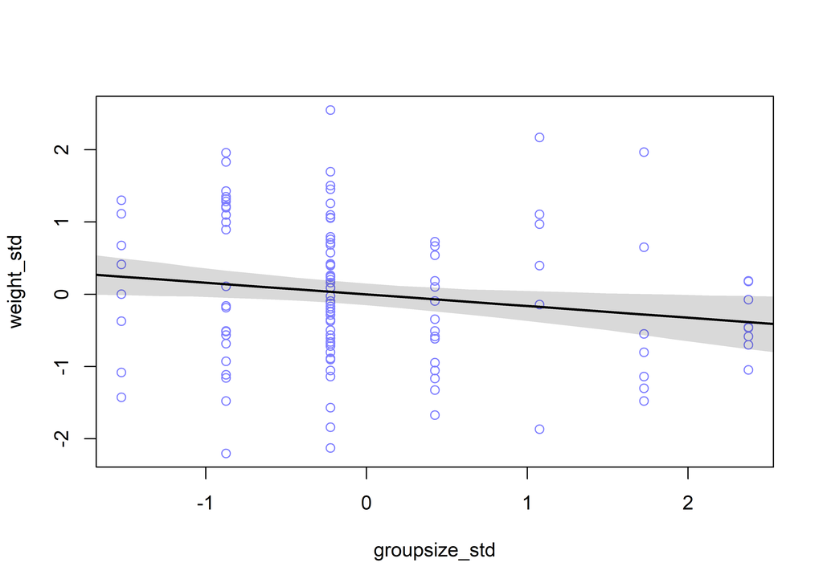

```r
# plotting body weight ~ area size
x_seq <- seq( from=-3 , to=3.2 , length.out=30 )
mu <- link( body_grsize_model , data=list(groupsize_std = x_seq) )
mu.mean <- apply( mu , 2, mean )
mu.PI <- apply( mu , 2 , PI )  # dont know how to set prob=0.95 in PI()


plot( weight_std ~ groupsize_std , data=foxes , col=rangi2 )
lines( x_seq , mu.mean ,lwd=2 )
shade( mu.PI , x_seq )
```

Area size do not seem to be good predictor of body weight of foxes. While the group size may have a relation with weight, as the bigger the group size, the smaller the weight of each fox member. The average fox has a -0.16 standard deviation less weight with 1 std deviation increase in group size.

```r
precis(body_grsize_model)
```

```
                mean         sd       5.5%       94.5%
a       4.960751e-08 0.08939545 -0.1428711  0.14287124
b_size -1.558038e-01 0.08977320 -0.2992787 -0.01232891
sigma   9.785863e-01 0.06384603  0.8765480  1.08062463
```

## 5H2. counterfactual

**Now fit a multiple linear regression with weight as the outcome and both area and groupsize as predictor variables. Plot the predictions of the model for each predictor, holding the other predictor constant at its mean. What does this model say about the importance of each variable? Why do you get different results than you got in the exercise just above?**

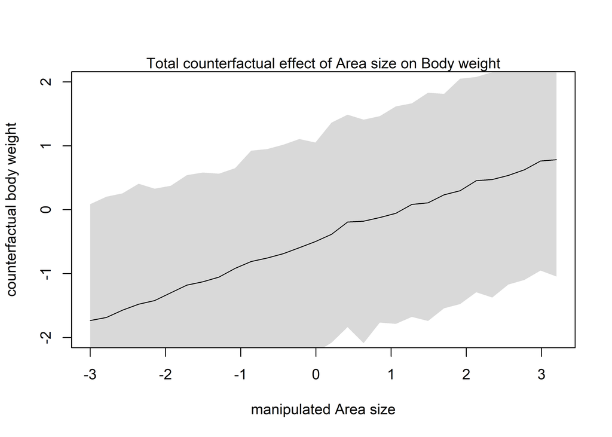

```r
# Third model: weight ~ area size + group size
body_area_grsize_model <- quap(
alist(
  weight_std ~ dnorm(mu, sigma),
  mu <- a + b_a*area_std + b_size*groupsize_std,
  a ~ dnorm( 0 , 0.5 ) ,
  b_a ~ dnorm( 0 , 0.5 ) ,
  b_size ~ dnorm( 0 , 0.5 ) ,
    sigma ~ dexp( 1 )
  ) , data = foxes )


# firstly, plotting body weight ~ area size. we try to keep group size constant
x_seq <- seq( from=-3 , to=3.2 , length.out=30 )

# prep data
sim_dat <- data.frame( area_std = x_seq )
# simulate group size and then weight, using x_seq
s <- sim( body_area_grsize_model , data=sim_dat , vars=c("groupsize_std","weight_std") )

# display counterfactual predictions
plot( sim_dat$area_std , colMeans(s$weight_std) , ylim=c(-2,2) , type="l" ,
    xlab="manipulated Area size" , ylab="counterfactual body weight"  )
shade( apply(s$weight_std,2,PI) , sim_dat$area_std )
mtext( "Total counterfactual effect of Area size on Body weight" )
```

Suddenly it became more clear that when controlling for group size, area seem correlated with body weight. So, maybe group size is masking for area size?

Secondly we keep area size constant and plot body weight ~ group size.

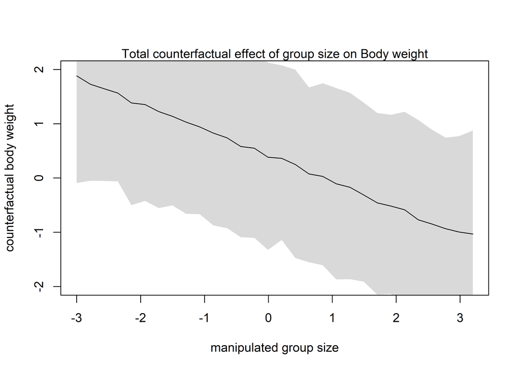

```r
sim_dat <- data.frame( groupsize_std = x_seq )
# simulate group size and then weight, using x_seq
s <- sim( body_area_grsize_model , data=sim_dat , vars=c("area_std","weight_std") )

# display counterfactual predictions
plot( sim_dat$groupsize_std , colMeans(s$weight_std) , ylim=c(-2,2) , type="l" ,
    xlab="manipulated group size" , ylab="counterfactual body weight"  )
shade( apply(s$weight_std,2,PI) , sim_dat$groupsize_std )
mtext( "Total counterfactual effect of group size on Body weight" )
```

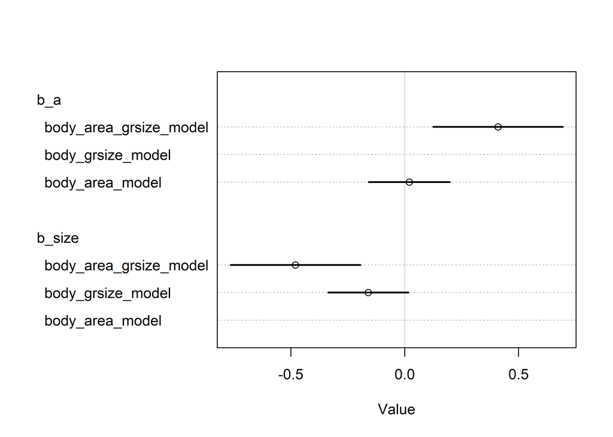

```r
plot( coeftab(body_area_model,body_grsize_model,body_area_grsize_model), par=c("b_a","b_size") )
```

Hmm, they have the exact same standard deviation…what’s the chance.

```r
precis(body_area_grsize_model, depth = 2)
```

```
                mean         sd       5.5%      94.5%
a       6.931961e-08 0.08614286 -0.1376729  0.1376730
b_a     4.059318e-01 0.14535211  0.1736311  0.6382326
b_size -4.820857e-01 0.14536207 -0.7144024 -0.2497690
sigma   9.418708e-01 0.06158186  0.8434511  1.0402905
```

## 5H3. adding avgfood

Finally, consider the `avgfood` variable. Fit two more multiple regressions:

1. (1) body weight as an additive function of avgfood and groupsize
2. (2) body weight as an additive function of all three variables, avgfood and groupsize and area.

Compare the results of these models to the previous models you’ve fit, in the first two exercises.

(a) Is avgfood or area a better predictor of body weight? If you had to choose one or the other to include in a model, which would it be? Support your assessment with any tables or plots you choose.

(b) When both avgfood or area are in the same model, their effects are reduced (closer to zero) and their standard errors are larger than when they are included in separate models. Can you explain this result?

```r
# First model: weight ~ avgfood + groupsize
body_food_grsize_model <- quap(
alist(
  weight_std ~ dnorm(mu, sigma),
  mu <- a + b_food*avgfood_std + b_size*groupsize_std,
  a ~ dnorm( 0 , 0.5 ) ,
  # b_a ~ dnorm( 0 , 0.5 ) ,
   b_food ~ dnorm( 0 , 0.5 ) ,
  b_size ~ dnorm( 0 , 0.5 ) ,
    sigma ~ dexp( 1 )
  ) , data = foxes )


# Second model: weight ~ avgfood + groupsize + area

body_food_grsize_area_model <- quap(
alist(
  weight_std ~ dnorm(mu, sigma),
  mu <- a + b_food*avgfood_std + b_size*groupsize_std +  b_a*area_std,
  a ~ dnorm( 0 , 0.5 ) ,
  b_a ~ dnorm( 0 , 0.5 ) ,
  b_food ~ dnorm( 0 , 0.5 ) ,
  b_size ~ dnorm( 0 , 0.5 ) ,
    sigma ~ dexp( 1 )
  ) , data = foxes )
```

### a) avgfood or area, which is the best predictor of body weight?

Make a comparison of estimated beta parameters in the models

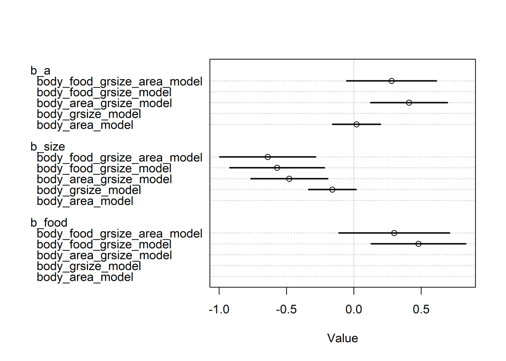

```r
plot( coeftab(body_area_model,
              body_grsize_model,
              body_area_grsize_model,
              body_food_grsize_model,
              body_food_grsize_area_model
              ), par=c("b_a","b_size", "b_food") )
```

Lets plot the two variables and see. Yeah, they seem very much correlated.

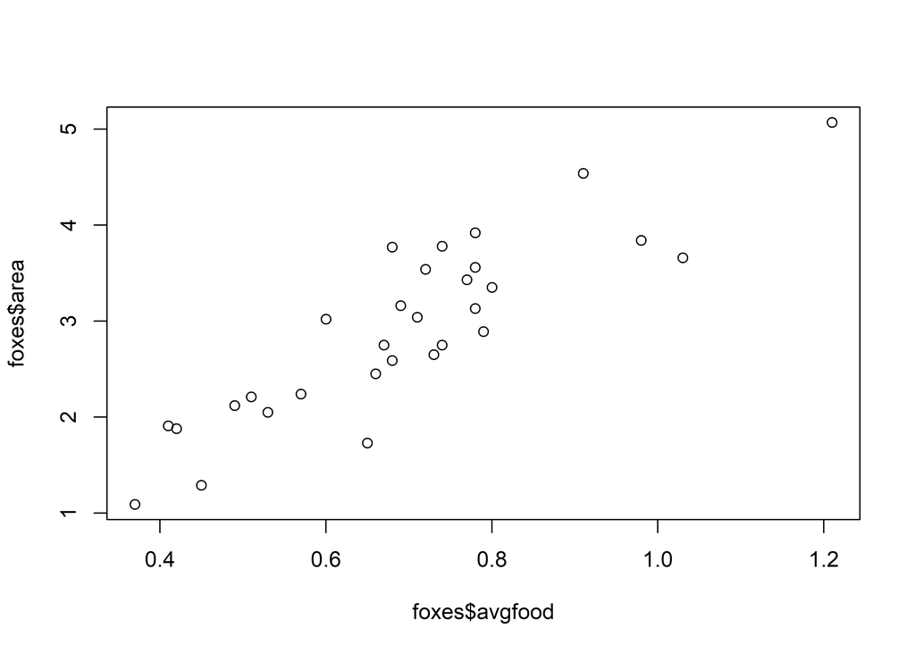

```r
plot(x = foxes$avgfood, y = foxes$area)
```

```r
cov(x = foxes$avgfood, y = foxes$area)
```

```
[1] 0.1625858
```

```r
precis(body_food_grsize_area_model) %>%
  View
```

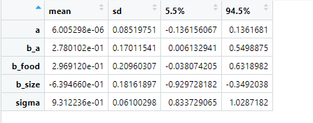

The estimate for area has a slightly lower sd than avgfood availability, so I would have went for area as a variable instead of avgfood. BUT…

!! Lets check a counterfactual first…

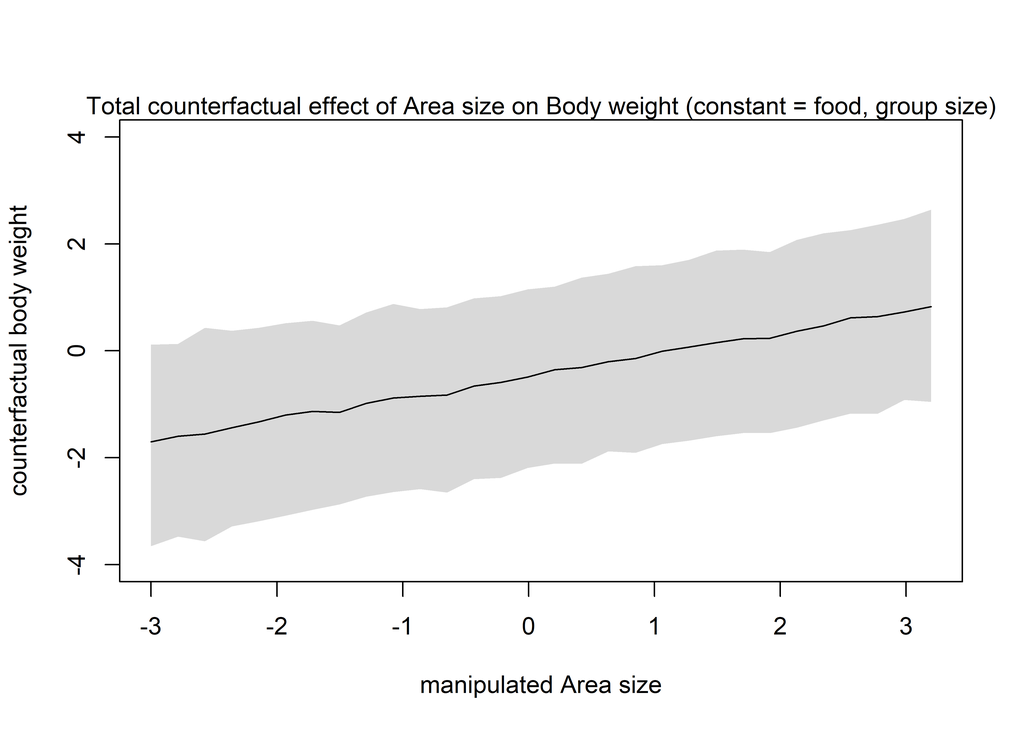

```r
# The model: body_food_grsize_area_model

# Firstly, plotting body weight ~ area size. we try to keep group size and food constant constant
x_seq <- seq( from=-3 , to=3.2 , length.out=30 )

# prep data
sim_dat <- data.frame( area_std = x_seq )
# simulate group size and then weight, using x_seq
s <- sim( body_area_grsize_model , data=sim_dat , vars=c("groupsize_std","weight_std", "avgfood_std") )

# display counterfactual predictions
plot( sim_dat$area_std , colMeans(s$weight_std) , ylim=c(-4,4) , type="l" ,
    xlab="manipulated Area size" , ylab="counterfactual body weight"  )
shade( apply(s$weight_std,2,PI) , sim_dat$area_std )
mtext( "Total counterfactual effect of Area size on Body weight (constant = food, group size)" )
```

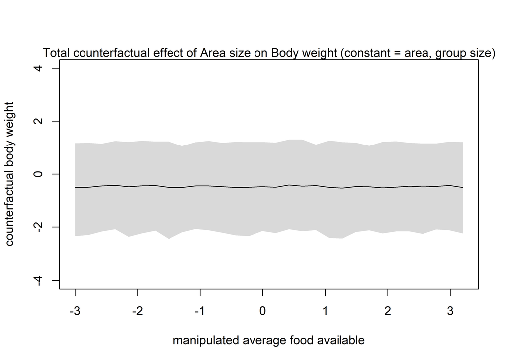

```r
# The model: body_food_grsize_area_model

# Firstly, plotting body weight ~ area size. we try to keep group size and area constant constant
x_seq <- seq( from=-3 , to=3.2 , length.out=30 )

# prep data
sim_dat <- data.frame( avgfood_std = x_seq )
# simulate group size and then weight, using x_seq
s <- sim( body_area_grsize_model , data=sim_dat , vars=c("groupsize_std","weight_std", "area_std") )

# display counterfactual predictions
plot( sim_dat$avgfood_std , colMeans(s$weight_std) , ylim=c(-4,4) , type="l" ,
    xlab="manipulated average food available" , ylab="counterfactual body weight"  )
shade( apply(s$weight_std,2,PI) , sim_dat$avgfood_std )
mtext( "Total counterfactual effect of Area size on Body weight (constant = area, group size)" )
```

### b) why standard errors of avgfood and area are larger when put together in the same model?

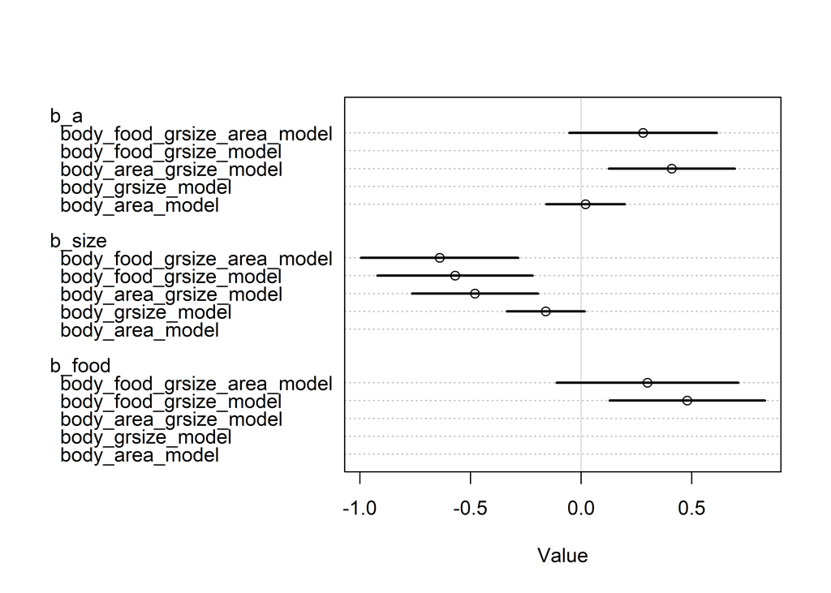

```r
plot( coeftab(body_area_model,
              body_grsize_model,
              body_area_grsize_model,
              body_food_grsize_model,
              body_food_grsize_area_model
              ), par=c("b_a","b_size", "b_food") )
```

Yes, b_food and b_a is smaller for the model that have both variables included compared to the models with only food in it.

Our guess is that they both account for the same mechanism = resources in the area, and with both variables included they are accounted for twice, therefor making it more accurate to readjust the parameters by reducing them. Though, not sure why the standard error increased for both.